# EDA on variables

DonghyunPark

2023-04-18

```r
library(tidyverse)
library(showtext)
library(GGally)
library(lubridate)
library(corrplot)

font_add_google("Nanum Gothic", "nanum")
showtext_auto()
```

# Data loading

```r
data <- read.csv("/Users/donghyunpark/Documents/Seoul National University/3rd year 1st semester/Data mining/1차 프로젝트/1차 프로젝트 데이터/화재발생피해_final.csv", fileEncoding = "euc-kr")
```

# Str for original data

```r
data %>% str
```

```
## 'data.frame':    22041 obs. of  39 variables:
##  $ 건물구조조              : chr  "철근콘크리트조" "Other" "철근콘크리트조" "철근콘크리트조" ...
##  $ 지상층수                : int  6 2 3 12 15 1 6 2 5 3 ...
##  $ 지하층수                : int  1 1 1 1 1 0 1 1 0 1 ...
##  $ 연면적                  : int  1133 248 1175 8989 8074 20 1470 199 510 300 ...
##  $ 바닥면적                : int  168 81 490 816 529 20 197 67 100 78 ...
##  $ 사망수                  : int  0 0 0 0 0 0 0 0 0 0 ...
##  $ 부상자수                : int  0 0 0 0 0 0 0 0 0 0 ...
##  $ 사망인명피해수          : int  0 0 0 0 0 0 0 0 0 0 ...
##  $ 재산피해금액            : int  13391 971 3669 374 30 50 107 124 315 128 ...
##  $ 화재발생연도            : int  2017 2017 2017 2017 2017 2017 2017 2017 2017 2017 ...
##  $ 계절구분명              : chr  "겨울" "겨울" "겨울" "겨울" ...
##  $ 화재발생시각            : num  0 33200 34200 124300 140000 ...
##  $ 화재발생월              : int  1 1 1 1 1 1 1 1 1 1 ...
##  $ 화재발생일              : int  1 1 1 1 1 1 1 1 1 2 ...
```

[output cut: 25 more lines]

# Data 전처리

## Eliminate some variables

주제가 재산 피해액 예측이라 사망 수, 부상자 수, 사망인명피해 수는 제외시켰다.

```r
data <- data %>%
  select(-"사망수", -"부상자수", -"사망인명피해수", -"화재발생시각")
```

## NA

NA가 하나라도 있는 행은 1개 제외 모든 관측치가 결측이었다.

결측치는 모두 제거하였다.

```r
data <- data %>% na.omit()
```

## 시간 변환

```r
data <- data %>%
  mutate(화재진압시간 = floor(화재진압시간/10000)*60*24 + floor((화재진압시간%%10000)/100)*60 + floor(화재진압시간/100), 출동소요시간 = floor(출동소요시간/10000)*60*24 + floor((출동소요시간%%10000)/100)*60 + floor(출동소요시간/100))
```

## Final Colnames

```r
data %>%
  colnames()
```

```
##  [1] "건물구조조"               "지상층수"
##  [3] "지하층수"                 "연면적"
##  [5] "바닥면적"                 "재산피해금액"
##  [7] "화재발생연도"             "계절구분명"
##  [9] "화재발생월"               "화재발생일"
## [11] "화재발생시"               "화재발생분"
## [13] "요일"                     "출동소요시간"
## [15] "화재진압시간"             "시군구명"
## [17] "현장소방서거리"           "현장안전센터거리"
## [19] "현장소방지역대거리"       "발화열원명"
## [21] "발화요인대분류명"         "최초착화물대분류명"
## [23] "시설장소대분류명"         "발화층명"
## [25] "그을음면적"               "화재보험의무가입대상여부"
## [27] "방화관리대상여부"         "다중이용업여부"
## [29] "시간단위기온"             "시간단위강수량"
## [31] "시간단위풍속"             "시간단위습도"
## [33] "시간단위적설량"           "시간단위가시거리"
## [35] "풍향"
```

# Exploratory Data Analysis

# 재산피해금액 추정

## 요약통계량

** 재산피해금액의 단위가 얼마인지 알 필요가 있음 **

```r
summary(data$재산피해금액)
```

```
##     Min.  1st Qu.   Median     Mean  3rd Qu.     Max.
##        0       31      132     6980      678 71613336
```

## Box-Cox transform

### 근거

재산피해금액의 range가 넓고, 단위 차이가 많이 나기 때문에 Box-Cox transform을 고려해보았다.

### BOX - COX 결과 (Full model 기준) & R square 기준

```r
Box_Cox_R2 <- c()

for(lambda1 in seq(0, 1, by = 0.05)){
  for(lambda2 in seq(-2, 2, by = 0.1)){
    if(lambda1 == 0){
      next
    }
    if(lambda2 == 0){
      data_lambda <- data %>%
        mutate(transform = log(재산피해금액 + lambda1))
    }else{
      data_lambda <- data %>%
        mutate(transform = ((재산피해금액 + lambda1)^lambda2 - 1 )/lambda2)
    }

    lm_full_lambda <- lm(transform ~ .-재산피해금액, data = data_lambda)

    Box_Cox_R2 <- c(Box_Cox_R2, c(lambda1, lambda2, summary(lm_full_lambda)$r.squared))
  }
}

as.data.frame(t(matrix(Box_Cox_R2, nrow = 3))) %>%
  rename("lambda1" = "V1", "lambda2" = "V2", "r.squared" = "V3") %>%
  arrange(desc(r.squared)) %>%
  head(5)
```

```
##   lambda1 lambda2 r.squared
## 1    1.00     0.2 0.4741991
## 2    0.95     0.2 0.4741364
## 3    0.90     0.2 0.4740708
## 4    0.85     0.2 0.4740019
## 5    0.80     0.2 0.4739293
```

### Log 변환

Box-Cox에서 lambda2 = 0일 때 시행하는 log 변환에서 best lambda1값이 얼마일 지 찾아보았다.

```r
as.data.frame(t(matrix(Box_Cox_R2, nrow = 3))) %>%
  rename("lambda1" = "V1", "lambda2" = "V2", "r.squared" = "V3") %>%
  filter(lambda2 == 0) %>%
  arrange(desc(r.squared)) %>%
  head(3)
```

```
##   lambda1 lambda2 r.squared
## 1    1.00       0 0.4234488
## 2    0.95       0 0.4229497
## 3    0.90       0 0.4224227
```

### BOX - COX 결과 (Full model 기준) & 1 to 100

```r
for(lambda1 in seq(1, 100, by = 1)){
  for(lambda2 in seq(-2, 2, by = 0.1)){
    if(lambda1 == 0){
      next
    }
    if(lambda2 == 0){
      data_lambda <- data %>%
        mutate(transform = log(재산피해금액 + lambda1))
    }else{
      data_lambda <- data %>%
        mutate(transform = ((재산피해금액 + lambda1)^lambda2 - 1 )/lambda2)
    }

    lm_full_lambda <- lm(transform ~ .-재산피해금액, data = data_lambda)

    Box_Cox_R2 <- c(Box_Cox_R2, c(lambda1, lambda2, summary(lm_full_lambda)$r.squared))
  }
}



as.data.frame(t(matrix(Box_Cox_R2, nrow = 3))) %>%
  rename("lambda1" = "V1", "lambda2" = "V2", "r.squared" = "V3") %>%
  arrange(desc(r.squared)) %>%
  head(5)
```

```
##   lambda1 lambda2 r.squared
## 1      19     0.2 0.4771030
## 2      18     0.2 0.4771024
## 3      20     0.2 0.4770998
## 4      17     0.2 0.4770975
## 5      21     0.2 0.4770933
```

### BOX - COX 결과 (Full model 기준) & lambda2 = 0.3

```r
for(lambda1 in seq(1, 3, by = 0.05)){
  data_lambda <- data %>%
    mutate(transform = ((재산피해금액 + lambda1)^(0.3) - 1 )/0.3)

  lm_full_lambda <- lm(transform ~ .-재산피해금액, data = data_lambda)

  Box_Cox_R2 <- c(Box_Cox_R2, c(lambda1, lambda2, summary(lm_full_lambda)$r.squared))
}

as.data.frame(t(matrix(Box_Cox_R2, nrow = 3))) %>%
  rename("lambda1" = "V1", "lambda2" = "V2", "r.squared" = "V3") %>%
  arrange(desc(r.squared)) %>%
  head(5)
```

```
##   lambda1 lambda2 r.squared
## 1      19     0.2 0.4771030
## 2      18     0.2 0.4771024
## 3      20     0.2 0.4770998
## 4      17     0.2 0.4770975
## 5      21     0.2 0.4770933
```

### Log 변환

```r
as.data.frame(t(matrix(Box_Cox_R2, nrow = 3))) %>%
  rename("lambda1" = "V1", "lambda2" = "V2", "r.squared" = "V3") %>%
  filter(lambda2 == 0) %>%
  arrange(desc(r.squared)) %>%
  head(3)
```

```
##   lambda1 lambda2 r.squared
## 1     100       0 0.4586943
## 2      99       0 0.4586599
## 3      98       0 0.4586250
```

## Plot both best Box-Cox within best Log

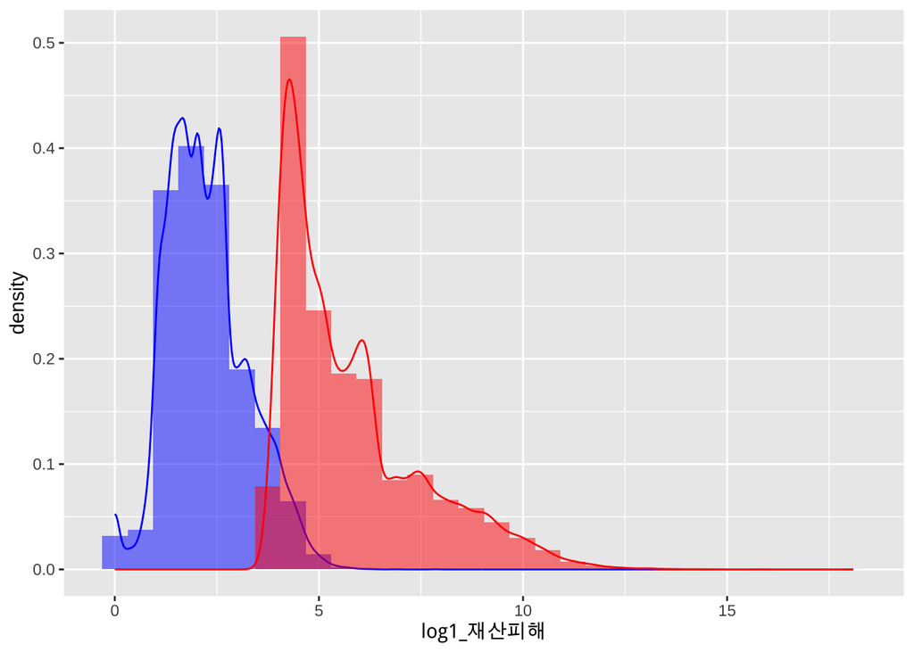

```r
q <- data %>%
  mutate(log1_재산피해 = log(재산피해금액 + 1, base = 10), log49_재산피해 = log(재산피해금액 + 49)) %>%
  ggplot() +
  geom_histogram(aes(x = log1_재산피해, y = ..density..), fill = "blue", alpha = 0.5)+
  geom_density(aes(x = log1_재산피해), color = "blue")+
  geom_histogram(aes(x = log49_재산피해, y = ..density..), fill = "red", alpha = 0.5)+
  geom_density(aes(x = log49_재산피해), color = "red")

q
```

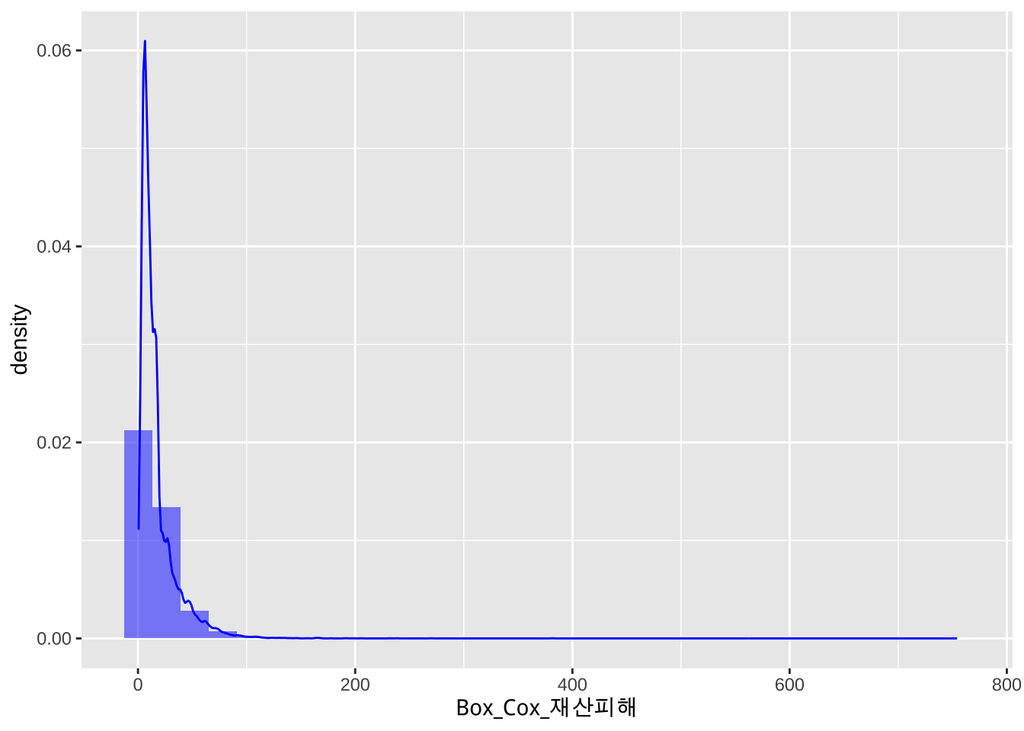

```r
q <- data %>%
  mutate(Box_Cox_재산피해 = ((재산피해금액 + 1.70)^0.3 - 1)/0.3) %>%
  ggplot() +
  geom_density(aes(x = Box_Cox_재산피해), color = "blue")+
  geom_histogram(aes(x = Box_Cox_재산피해, y = ..density..), fill = "blue", alpha = 0.5)

q
```

## Transform 각각에 대한 Boxplot

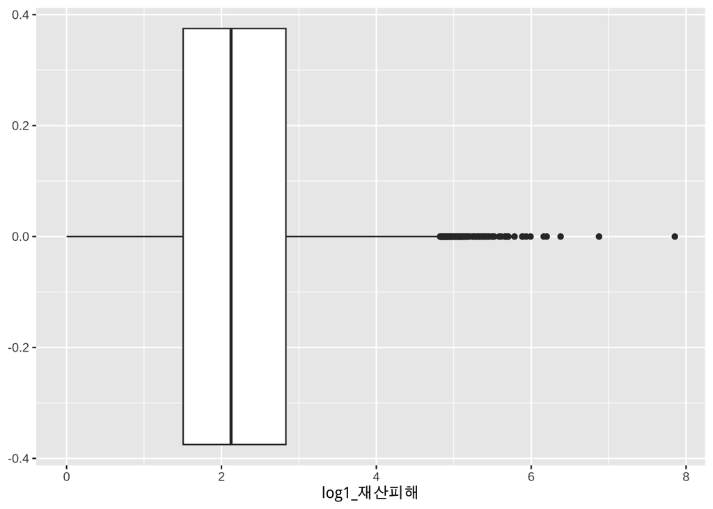

```r
par(mfrow = c(1,3))
data %>%
  mutate(Box_Cox_재산피해 = ((재산피해금액 + 1.70)^0.3 - 1)/0.3, log1_재산피해 = log(재산피해금액 + 1, base = 10), log49_재산피해 = log(재산피해금액 + 49)) %>%
  ggplot()+
  geom_boxplot(aes(x = log1_재산피해))
```

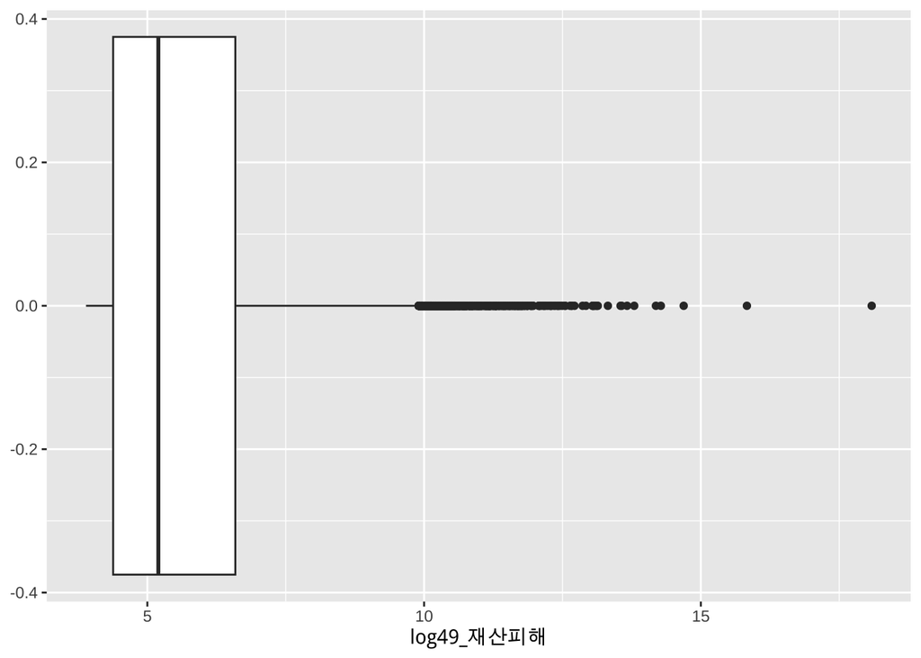

```r
data %>%
  mutate(Box_Cox_재산피해 = ((재산피해금액 + 1.70)^0.3 - 1)/0.3, log1_재산피해 = log(재산피해금액 + 1, base = 10), log49_재산피해 = log(재산피해금액 + 49)) %>%
  ggplot()+
  geom_boxplot(aes(x = log49_재산피해))
```

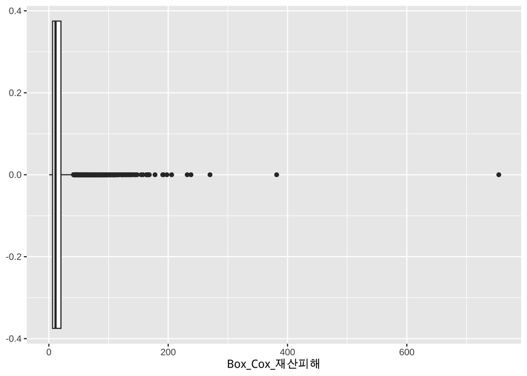

```r
data %>%
  mutate(Box_Cox_재산피해 = ((재산피해금액 + 1.70)^0.3 - 1)/0.3, log1_재산피해 = log(재산피해금액 + 1, base = 10), log49_재산피해 = log(재산피해금액 + 49)) %>%
  ggplot()+
  geom_boxplot(aes(x = Box_Cox_재산피해))
```

# Log(재산피해금액 + 1) 선택

근거는 충분하지 않으나 EDA 상에서 진행을 위해 이렇게 선택. Skewness가 적어서 데이터간의 관계를 보기 수월할 것으로 예상

```r
data <- data %>%
  mutate(재산피해금액 = log(재산피해금액 + 1))
```

# 건물 : 건물구조조, 지상 층수, 지하 층수, 연면적, 바닥면적, 발화층명, 그을음면적

## 건물 데이터 종류

### 이산형

```r
unique(data$건물구조조)
```

```
## [1] "철근콘크리트조" "Other"          "샌드위치패널조" "벽돌조"
## [5] "블록조"         "목조"           "컨테이너조"     "철골조"
```

```r
unique(data$지상층수)
```

```
##  [1]   6   2   3  12  15   1   5  21  16  20   7   4   0  13  35  19  10  25  37
## [20]   9  28  18  11   8  24  17  23  14  22  32  26  27  34  41  46  29  47  30
## [39]  40  36  43  31  54  50  39  38  33  45  55  49  53  48  58  42 115  66 119
```

```r
unique(data$지하층수)
```

```
##  [1]  1  0  3  2  4  5  6  8  7 94  9 15 14 18 30 10 11
```

```r
unique(data$발화층명)
```

```
##  [1]   3  -1   2  11   1   5   4  -2   6  14   7  15  -5   8  18  -3  10   9  13
## [20]  12  20  16  17  -4  26  -6  19  24  -8  23  41  30  21  27  22  -7  32  31
## [39]  25  33  36  39  28  29  42 -10  38
```

```r
unique(data$시설장소대분류명)
```

```
##  [1] "단독주택"       "공동주택"       "생활서비스"     "기타서비스"
##  [5] "판매/업무시설"  "의료/복지시설"  "운수자동차시설" "산업시설"
##  [9] "집합시설"       "기타주택"       "교육시설"       "Other"
```

#### 건물구조조

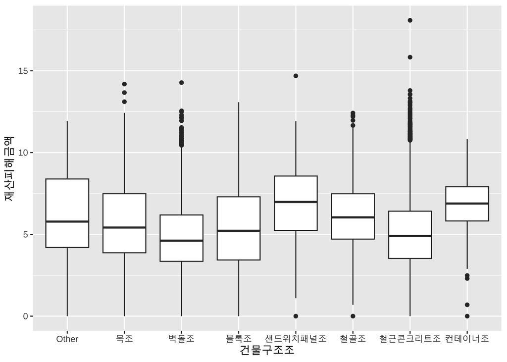

```r
data %>%
  ggplot(aes(x = 건물구조조, y = 재산피해금액))+
  geom_boxplot()
```

```r
data %>%
  group_by(건물구조조) %>%
  summarise(n = n())
```

```
## # A tibble: 8 × 2
##   건물구조조         n
##   <chr>          <int>
## 1 Other            272
## 2 목조             262
## 3 벽돌조          2911
## 4 블록조           259
## 5 샌드위치패널조   125
## 6 철골조           159
## 7 철근콘크리트조 17480
## 8 컨테이너조        75
```

#### 지상층수

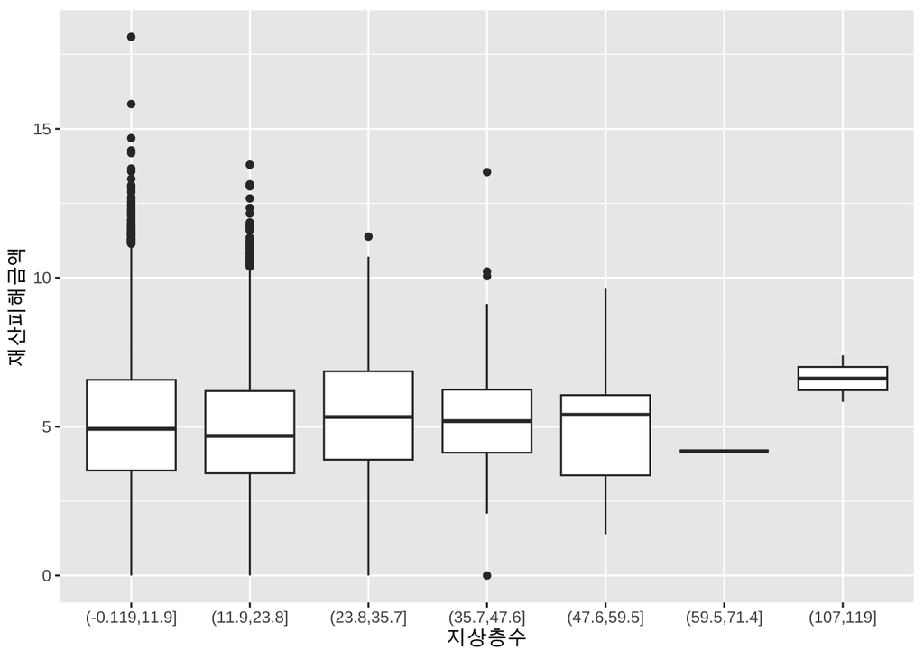

```r
data %>%
  mutate(지상층수 = cut(지상층수, 10)) %>%
  ggplot(aes(x = 지상층수, y = 재산피해금액))+
  geom_boxplot()
```

#### 지하층수

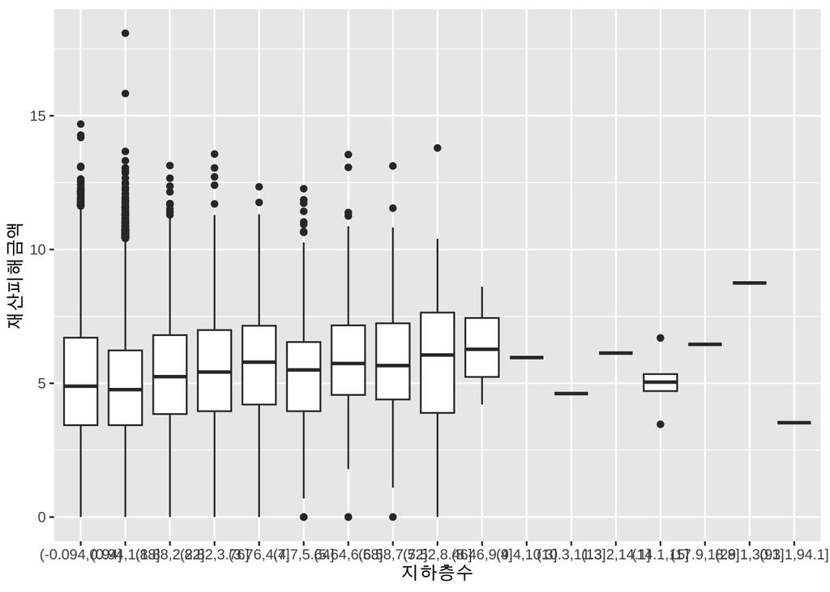

```r
data %>%
  mutate(지하층수 = cut(지하층수, 100)) %>%
  ggplot(aes(x = 지하층수, y = 재산피해금액))+
  geom_boxplot()
```

#### 발화층명

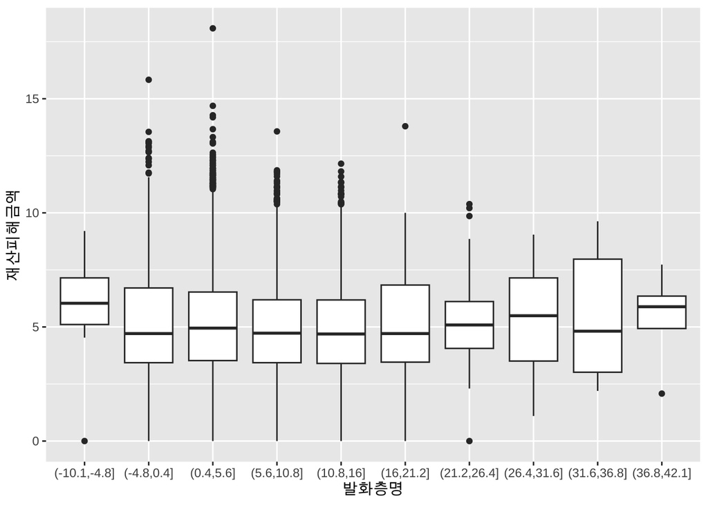

```r
data %>%
  mutate(발화층명 = cut(발화층명, 10)) %>%
  ggplot(aes(x = 발화층명, y = 재산피해금액))+
  geom_boxplot()
```

#### 시설장소대분류명

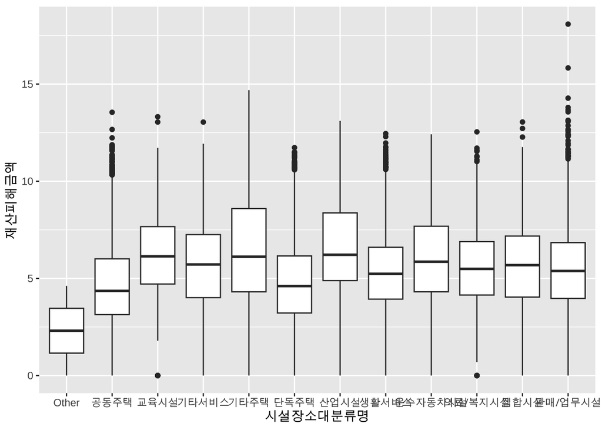

```r
data %>%
  ggplot(aes(x = 시설장소대분류명, y = 재산피해금액))+
  geom_boxplot()
```

### 연속형

#### 연면적

연면적의 경우 Outlier가 존재.

```r
data%>%
  filter(연면적 > 2e+08)
```

```
##       건물구조조 지상층수 지하층수    연면적 바닥면적 재산피해금액 화재발생연도
## 1 철근콘크리트조       12        3 302677696     8454     5.549076         2020
##   계절구분명 화재발생월 화재발생일 화재발생시 화재발생분   요일 출동소요시간
## 1       여름          7         12         17         24 일요일          122
##   화재진압시간 시군구명 현장소방서거리 현장안전센터거리 현장소방지역대거리
## 1          732   강서구              1                1                  0
##         발화열원명 발화요인대분류명 최초착화물대분류명 시설장소대분류명
## 1 기기 전도/복사열      기계적 요인          전기/전자         공동주택
##   발화층명 그을음면적 화재보험의무가입대상여부 방화관리대상여부 다중이용업여부
## 1       -1          0                        Y                Y              N
##   시간단위기온 시간단위강수량 시간단위풍속 시간단위습도 시간단위적설량
## 1         24.5            0.1          1.6           75              0
##   시간단위가시거리 풍향
## 1             1532 북동
```

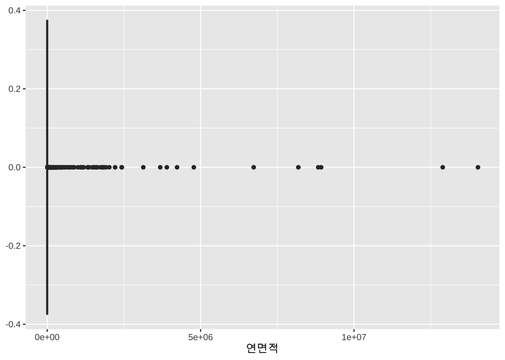

```r
par(mfrow = c(1,2))
data %>%
  filter(연면적 < 2e+08)%>%
  ggplot(aes(x = 연면적))+
  geom_boxplot()
```

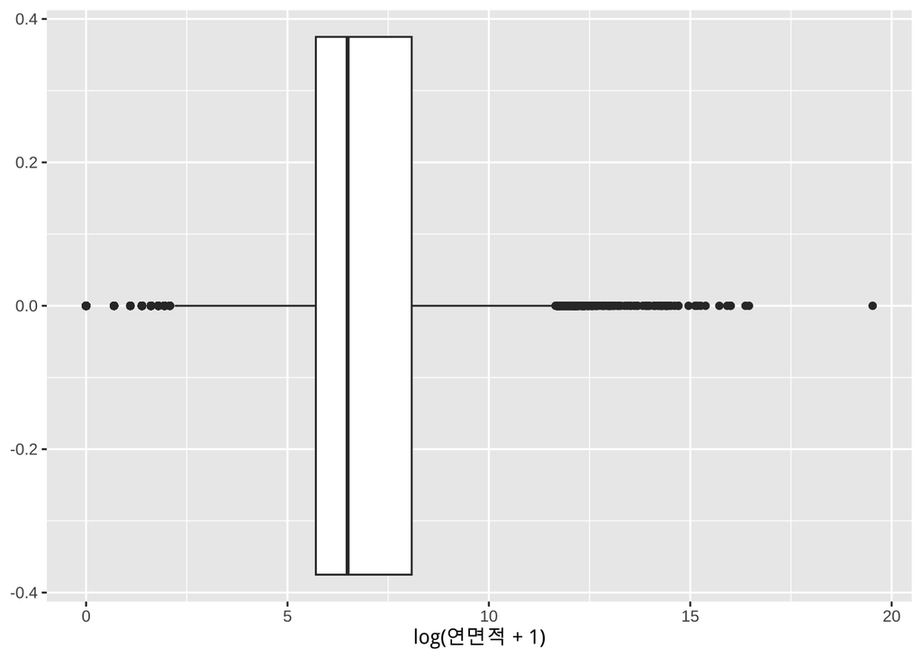

```r
data %>%
  ggplot(aes(x = log(연면적 + 1)))+
  geom_boxplot()
```

Log 변환이 더 적합할 것으로 예상.

#### Plot 연면적 vs 재산피해량

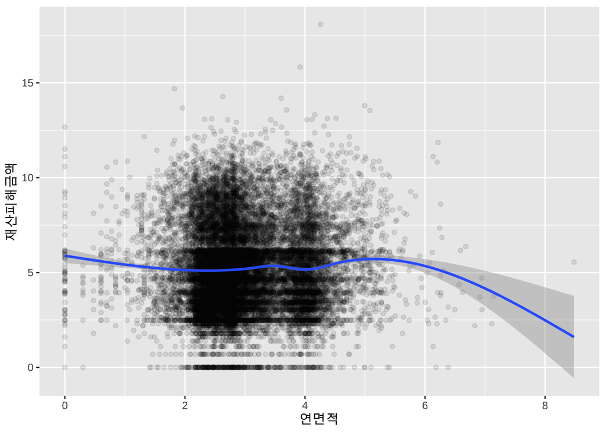

```r
data %>%
  mutate(연면적 = log(연면적 + 1, base = 10))%>%
  ggplot(aes(연면적, 재산피해금액))+
  geom_point(alpha = 0.1)+
  geom_smooth()
```

#### 바닥면적

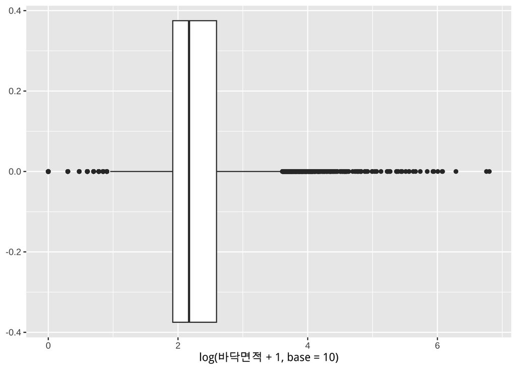

```r
data %>%
  ggplot()+
  geom_boxplot(aes(x = log(바닥면적 + 1, base = 10)))
```

Log 변환이 더 적합할 것으로 예상.

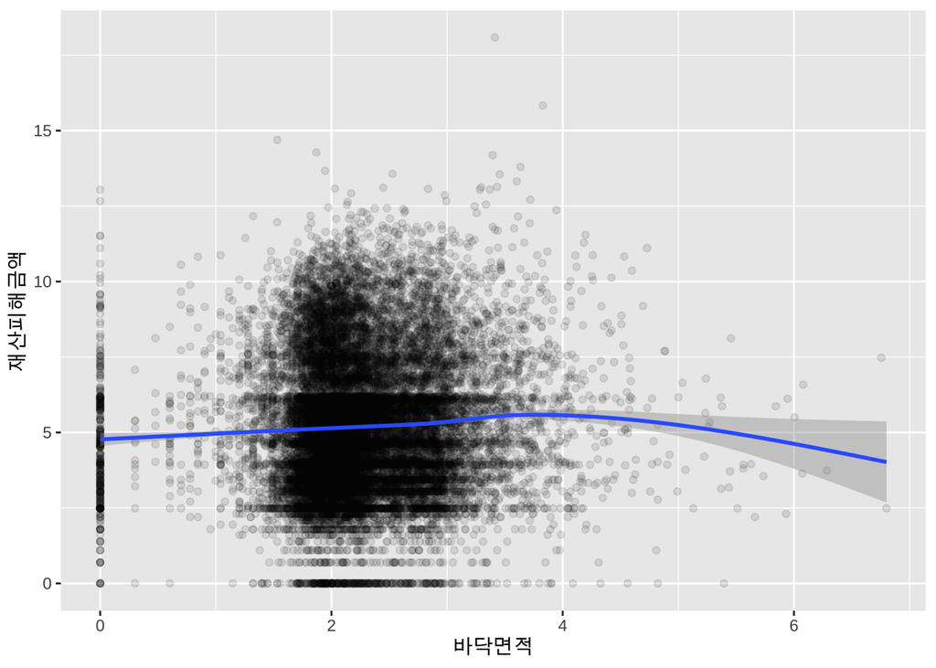

```r
data %>%
  mutate(바닥면적 = log(바닥면적 + 1, base = 10))%>%
  ggplot(aes(바닥면적, 재산피해금액))+
  geom_point(alpha = 0.1)+
  geom_smooth()
```

#### 연면적 vs 바닥면적

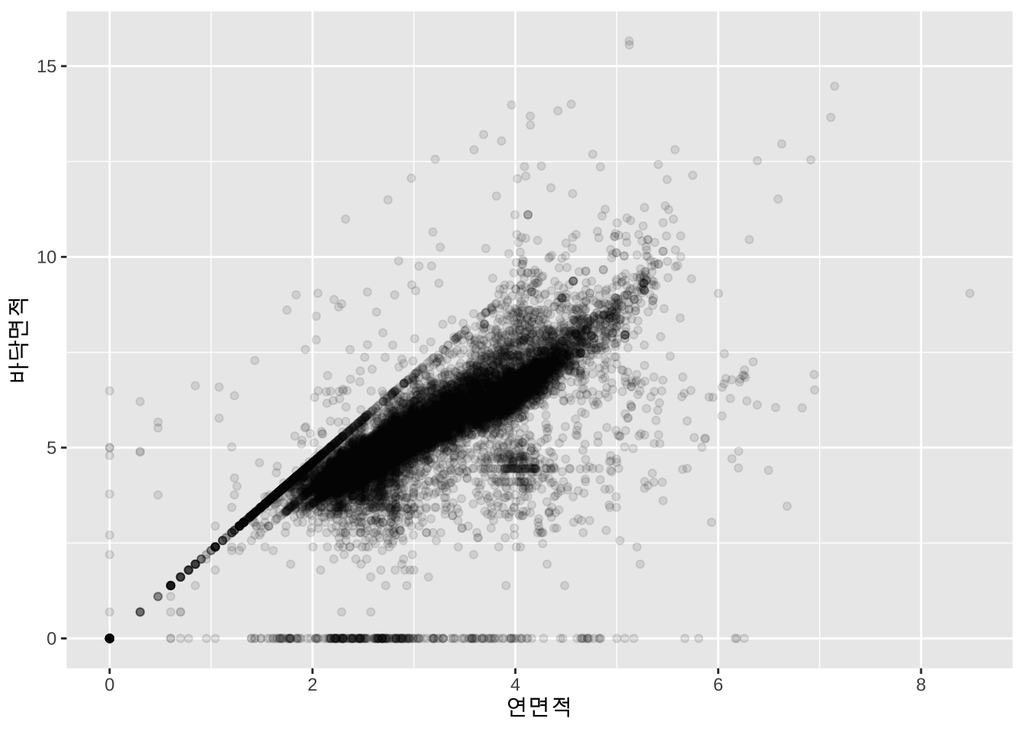

```r
data %>%
  mutate(연면적 = log(연면적+1, base = 10), 바닥면적 = log(바닥면적 + 1), base = 10)%>%
  ggplot()+
  geom_point(aes(연면적, 바닥면적), alpha = 0.1)
```

#### 바닥면적 = 0

```r
data %>%
  filter(바닥면적 == 0) %>%
  select(건물구조조, 지상층수, 지하층수, 연면적, 시설장소대분류명)
```

```
##         건물구조조 지상층수 지하층수  연면적 시설장소대분류명
## 1   철근콘크리트조       25        4       0         공동주택
## 2   철근콘크리트조        3        1     495         공동주택
## 3   철근콘크리트조        4        1     575       생활서비스
## 4   철근콘크리트조        6        0     624         공동주택
## 5   철근콘크리트조        3        1     317       생활서비스
## 6   철근콘크리트조       12        2 1805702         공동주택
## 7   철근콘크리트조        5        1     485       생활서비스
## 8             목조        1        1      76       생활서비스
## 9   철근콘크리트조        3        1     214    판매/업무시설
## 10  철근콘크리트조       25        7   44200         공동주택
## 11          벽돌조        2        1     311         공동주택
## 12  철근콘크리트조        4        1    1495    판매/업무시설
## 13  철근콘크리트조        3        1     658         공동주택
## 14  철근콘크리트조        5        0     408         공동주택
```

[output cut: 330 more lines]

바닥면적에는 결측치가 있는 것으로 보임. 0이 결측치로 입력된 것이 아닐까 추정. 연면적과 바닥면적은 유의미한 상관관계가 있기 때문에 바닥면적을 제외하고 분석하는 것이 좋아보임. 혹은 해당 데이터셋을 제외하여 분석 진행.

#### 연면적 = 0

```r
data %>%
  filter(연면적 == 0) %>%
  select(건물구조조, 지상층수, 지하층수, 연면적, 시설장소대분류명)
```

```
##        건물구조조 지상층수 지하층수 연면적 시설장소대분류명
## 1  철근콘크리트조       25        4      0         공동주택
## 2  철근콘크리트조        1        0      0       기타서비스
## 3          벽돌조        3        1      0         단독주택
## 4          벽돌조        1        1      0         단독주택
## 5  철근콘크리트조        5        2      0         공동주택
## 6  철근콘크리트조        1        1      0         공동주택
## 7          벽돌조        1        0      0       생활서비스
## 8  철근콘크리트조        3        1      0         단독주택
## 9  철근콘크리트조        1        0      0         단독주택
## 10 철근콘크리트조        5        0      0         공동주택
## 11 철근콘크리트조        0        0      0         공동주택
## 12 철근콘크리트조        5        0      0         공동주택
## 13 철근콘크리트조       15        1      0         공동주택
## 14 철근콘크리트조       15        0      0         공동주택
```

[output cut: 48 more lines]

연면적이 0 인 데이터도 회귀 분석의 성능을 저하시키는 요인이 될 것으로 추정

#### 바닥면적 0 제외 시 재산 피해금액

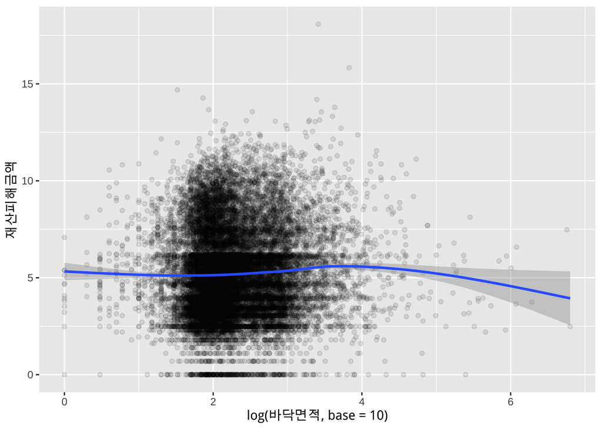

```r
data %>%
  filter(바닥면적 > 0)%>%
  ggplot(aes(x = log(바닥면적, base = 10), y = 재산피해금액))+
  geom_point(alpha = 0.1)+
  geom_smooth()
```

별다른 경향성이 없어 보이고, 연면적과 바닥면적을 변수로 추가하는 것이 좋을 지는 모름

#### 그을음 면적

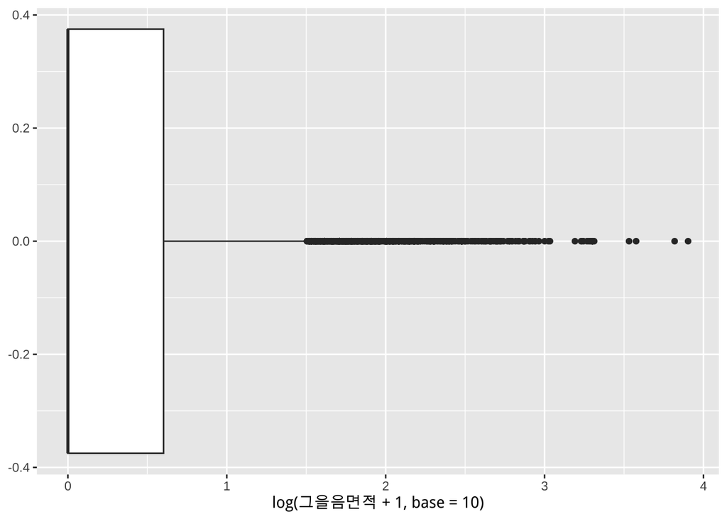

```r
data %>%
  ggplot()+
  geom_boxplot(aes(x = log(그을음면적 + 1, base = 10)))
```

그을음면적의 중앙값이 0이다.

```r
summary(data$그을음면적)
```

```
##    Min. 1st Qu.  Median    Mean 3rd Qu.    Max.
##    0.00    0.00    0.00   10.72    3.00 8000.00
```

#### 그을음 면적 > 0 이면 재산 피해량이 큰가?

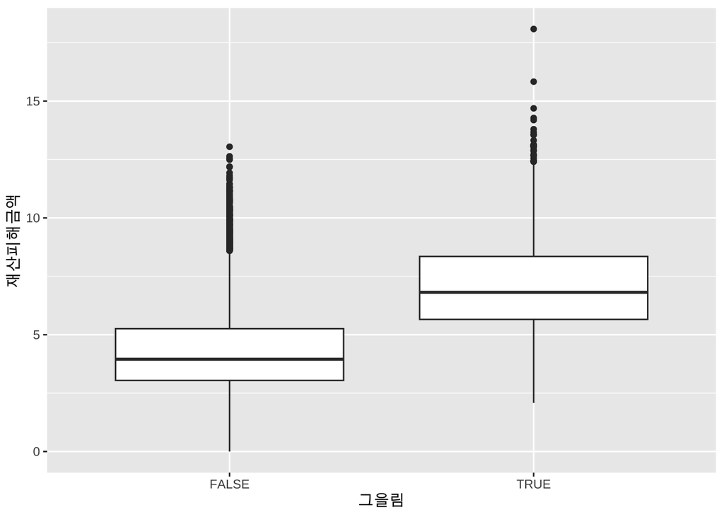

```r
data %>%
  mutate(그을림 = 그을음면적 > 0) %>%
  ggplot()+
  geom_boxplot(aes(x=그을림, y = 재산피해금액))
```

#### 그을음 면적 > 0 & 재산피해금액

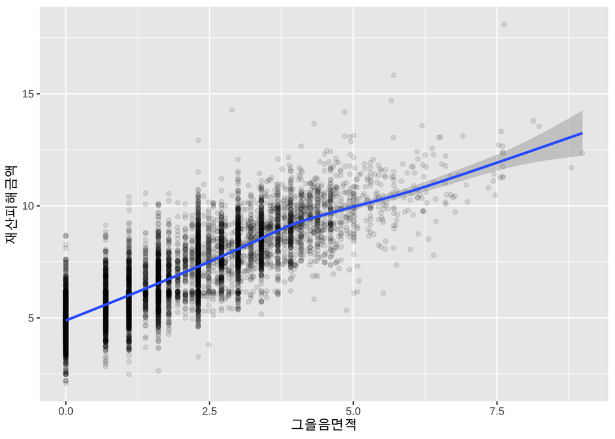

```r
data %>%
  filter(그을음면적 > 0) %>%
  mutate(그을음면적 = log(그을음면적)) %>%
  ggplot(aes(x = 그을음면적, y = 재산피해금액))+
  geom_point(alpha = 0.1)+
  geom_smooth()
```

Linearity도 어느정도 만족한다. 따라서 그을음면적을 변수로 추가한다면 I(그을음면적 > 0), log(그을음면적 + 1)을 사용하는 것이 좋을 것이다.

### 변수간 교호작용 분석

ANOVA로 하나씩 유의한 교호작용을 보았다.

시설장소대분류명 + 지상층수, 지하층수, 발화층명, 건물구조조

건물구조조 + 지하층수, 지상층수(*), 발화층명

그을음면적 + 지하층수, 지상층수, 발화층명, 건물구조조

# 건물 EDA 모델 Improvement

## 변화

1. 연면적, 바닥면적 로그변환, 그을음 변수 추가
2. 교호작용 추가

```r
modeling_data <- data %>%
  mutate(연면적 = log(연면적 + 1), 바닥면적 = log(바닥면적 + 1), 그을음 = I(그을음면적 > 0), 그을음 = log(그을음 + 1))

modeling1_lm <- lm(재산피해금액 ~ ., data = modeling_data)
modeling2_lm <- lm(재산피해금액 ~ . + 시설장소대분류명 : 지상층수 + 시설장소대분류명 : 지하층수 + 시설장소대분류명 : 발화층명 + 시설장소대분류명 : 건물구조조 + 지하층수 : 건물구조조 + 지상층수 : 건물구조조 + 발화층명 : 건물구조조 + 그을음면적 : 지하층수 + 그을음면적 : 지상층수 + 그을음면적 : 발화층명 + 그을음면적 : 건물구조조 + 시설장소대분류명 : 그을음면적 + 그을음 : 지하층수 + 그을음 : 지상층수 + 그을음 : 발화층명 + 그을음 : 건물구조조 + 시설장소대분류명 : 그을음, data = modeling_data)
basic_lm <- lm(재산피해금액 ~ ., data = data)
```

```r
summary(basic_lm)$adj.r.squared
```

```
## [1] 0.4204897
```

```r
summary(modeling1_lm)$adj.r.squared
```

```
## [1] 0.5640167
```

```r
summary(modeling2_lm)$adj.r.squared
```

```
## [1] 0.5822908
```

# 소방서 관련 : 현장소방서거리, 현장안전센터거리, 현장소방지역대거리, 출동소요시간, 화재진압시간

## 현장소방지역대거리

대부분의 값이 0이다

```r
sum(data$현장소방지역대거리 > 0)
```

```
## [1] 138
```

그래서 Boxplot을 그려보니

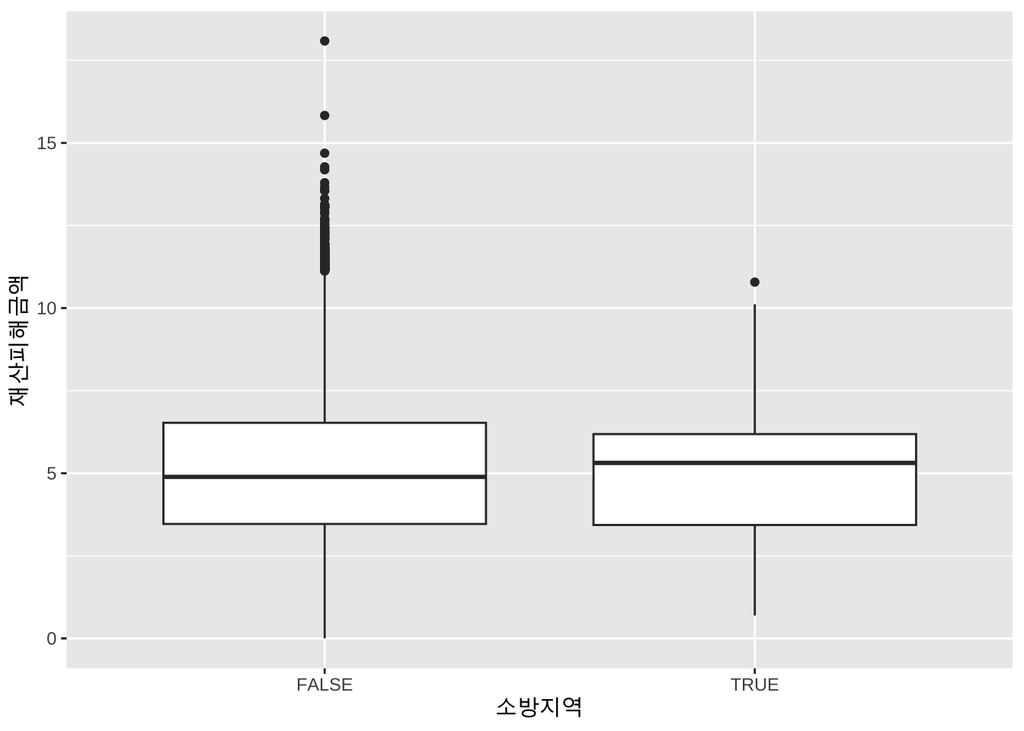

```r
data %>%
  mutate(소방지역 = 현장소방지역대거리 > 0) %>%
  ggplot(aes(x = 소방지역, y = 재산피해금액))+
  geom_boxplot()
```

별다른 차이점을 발견하지 못했다.

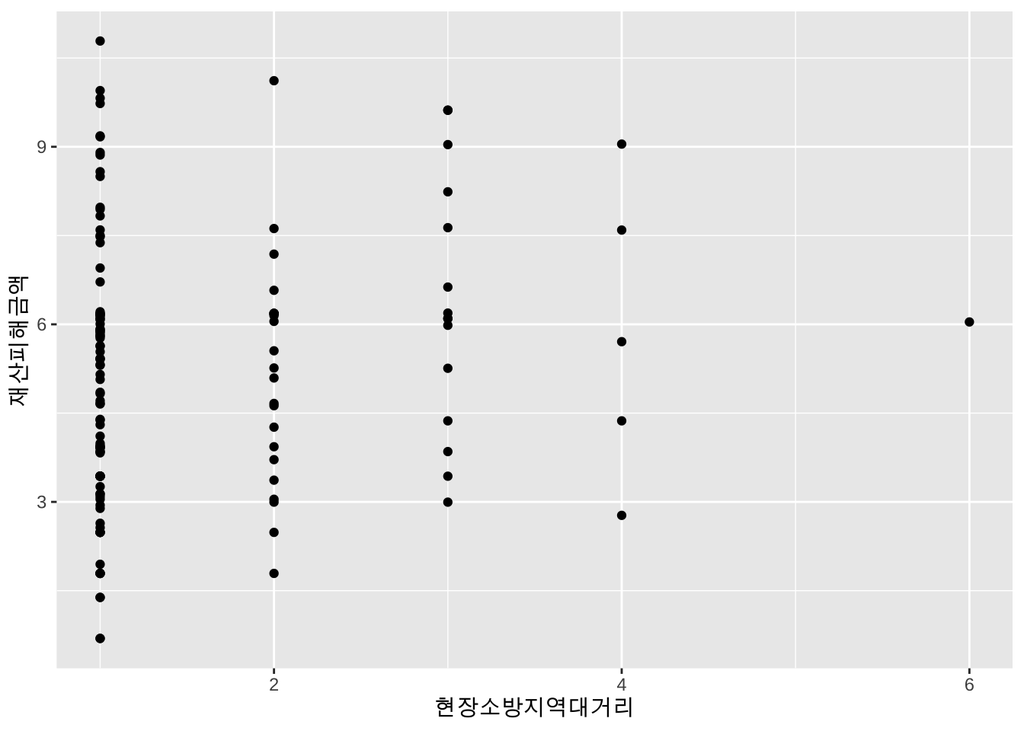

```r
data %>%
  filter(현장소방지역대거리 > 0)%>%
  ggplot(aes(x = 현장소방지역대거리, y = 재산피해금액))+
  geom_point()
```

변수에서 제외하여도 무방하다.

## 현장안전센터거리

```r
data%>%
  group_by(현장안전센터거리)%>%
  summarise(n = n())
```

```
## # A tibble: 13 × 2
##    현장안전센터거리     n
##               <int> <int>
##  1                0   939
##  2                1  9842
##  3                2  7807
##  4                3  2321
##  5                4   482
##  6                5    95
##  7                6    32
##  8                7    14
##  9                8     4
## 10                9     3
## 11               10     2
## 12               16     1
## 13               20     1
```

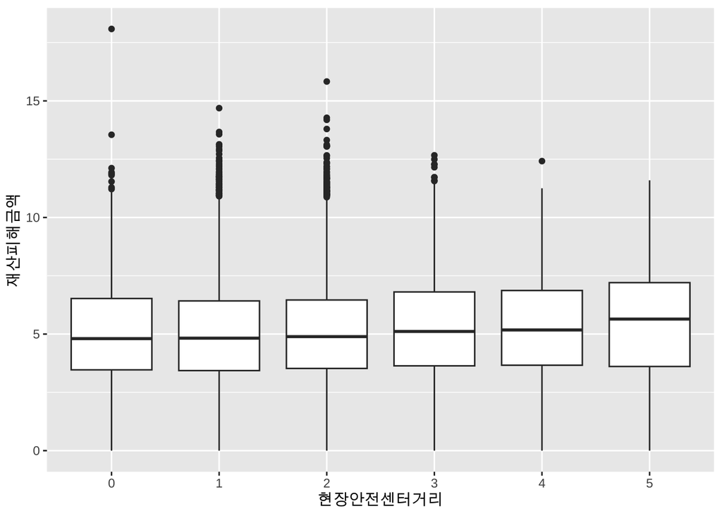

```r
data %>%
  mutate(현장안전센터거리 = ifelse(현장안전센터거리 > 5, 5 , 현장안전센터거리)) %>%
  mutate(현장안전센터거리 = as.factor(현장안전센터거리))%>%
  ggplot(aes(현장안전센터거리, 재산피해금액))+
  geom_boxplot()
```

별다른 차이가 관측되지 않았다.

### 현장소방서거리

```r
data%>%
  group_by(현장소방서거리)%>%
  summarise(n = n())
```

```
## # A tibble: 19 × 2
##    현장소방서거리     n
##             <int> <int>
##  1              0   224
##  2              1  2794
##  3              2  4913
##  4              3  5393
##  5              4  3977
##  6              5  2122
##  7              6  1054
##  8              7   532
##  9              8   317
## 10              9   128
## 11             10    47
## 12             11    22
## 13             12     7
## 14             13     4
## 15             14     3
## 16             20     2
## 17             24     1
## 18             40     2
## 19             44     1
```

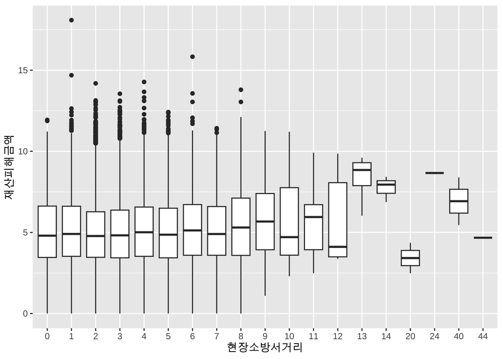

```r
data %>%
  mutate(현장소방서거리 = as.factor(현장소방서거리)) %>%
  ggplot(aes(현장소방서거리, 재산피해금액))+
  geom_boxplot()
```

소방서거리가 멀면 재산피해금액이 주로 높은 것을 확인할 수 있다.

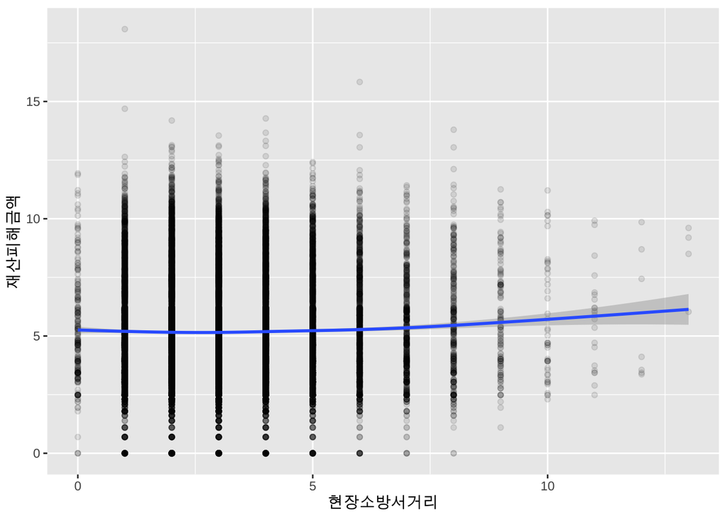

```r
data %>%
  filter(현장소방서거리 <= 13)%>%
  ggplot(aes(현장소방서거리, 재산피해금액))+
  geom_point(alpha = 0.1)+
  geom_smooth()
```

#### Exponent 항 찾기

```r
Exponent_R2 <- c()

for(lambda in seq(0, 2, by = 0.05)){
  data_lambda <- data %>%
        mutate(현장소방서거리 = 현장소방서거리^lambda)

  lm_full_lambda <- lm(재산피해금액 ~ ., data = data_lambda)

  Exponent_R2 <- c(Exponent_R2, c(lambda, summary(lm_full_lambda)$r.squared))
}

as.data.frame(t(matrix(Exponent_R2, nrow = 2))) %>%
  rename("lambda" = "V1", "r.squared" = "V2") %>%
  arrange(desc(r.squared)) %>%
  head(5)
```

```
##   lambda r.squared
## 1   0.10 0.4235009
## 2   0.15 0.4234999
## 3   0.05 0.4234962
## 4   0.20 0.4234957
## 5   0.25 0.4234905
```

```r
as.data.frame(t(matrix(Exponent_R2, nrow = 2))) %>%
  rename("lambda" = "V1", "r.squared" = "V2") %>%
  filter(lambda == 1)
```

```
##   lambda r.squared
## 1      1 0.4234488
```

### 출동소요시간

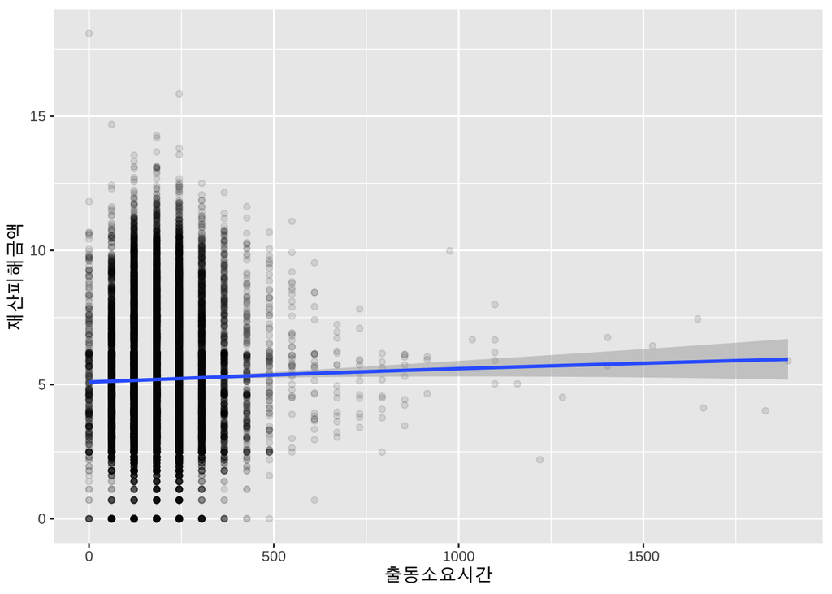

```r
data %>%
  filter(출동소요시간 < 2000)%>%
  ggplot(aes(출동소요시간, 재산피해금액))+
  geom_point(alpha = 0.1)+
  geom_smooth()
```

재산피해금액이 0인 곳은 보면 출동소요시간이 1000 이하였다. 전체적으로 출동 소요시간이 길 수록 재산피해금액이 큰 걸 확인할 수 있다.

```r
Exponent_R2 <- c()

for(lambda in seq(0, 2, by = 0.05)){
  data_lambda <- data %>%
        mutate(출동소요시간 = 출동소요시간^lambda)

  lm_full_lambda <- lm(재산피해금액 ~ ., data = data_lambda)

  Exponent_R2 <- c(Exponent_R2, c(lambda, summary(lm_full_lambda)$r.squared))
}

as.data.frame(t(matrix(Exponent_R2, nrow = 2))) %>%
  rename("lambda" = "V1", "r.squared" = "V2") %>%
  arrange(desc(r.squared)) %>%
  head(5)
```

```
##   lambda r.squared
## 1   0.55 0.4235029
## 2   0.50 0.4235027
## 3   0.60 0.4235013
## 4   0.45 0.4235001
## 5   0.65 0.4234982
```

```r
as.data.frame(t(matrix(Exponent_R2, nrow = 2))) %>%
  rename("lambda" = "V1", "r.squared" = "V2") %>%
  filter(lambda == 1)
```

```
##   lambda r.squared
## 1      1 0.4234488
```

### 화재진압시간

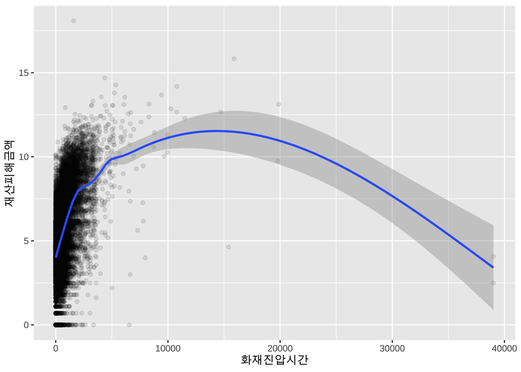

```r
data %>%
  ggplot(aes(화재진압시간, 재산피해금액))+
  geom_point(alpha = 0.1)+
  geom_smooth()
```

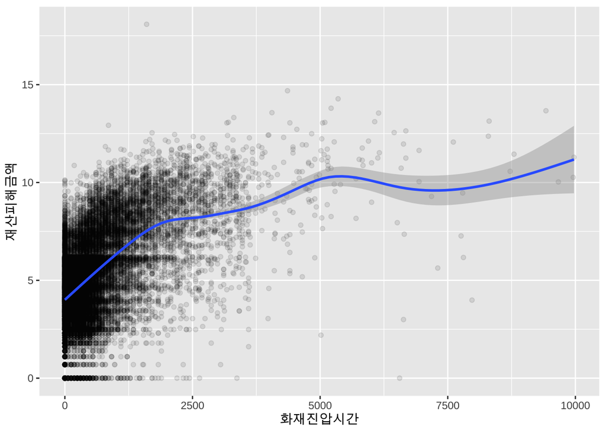

```r
data %>%
  filter(화재진압시간 < 10000)%>%
  ggplot(aes(화재진압시간, 재산피해금액))+
  geom_point(alpha = 0.1)+
  geom_smooth()
```

화재 진압시간에 따라서 재산 피해금액이 명확하게 늘어난다. 반면 몇 이상치는 경향성을 따르지 않는다.

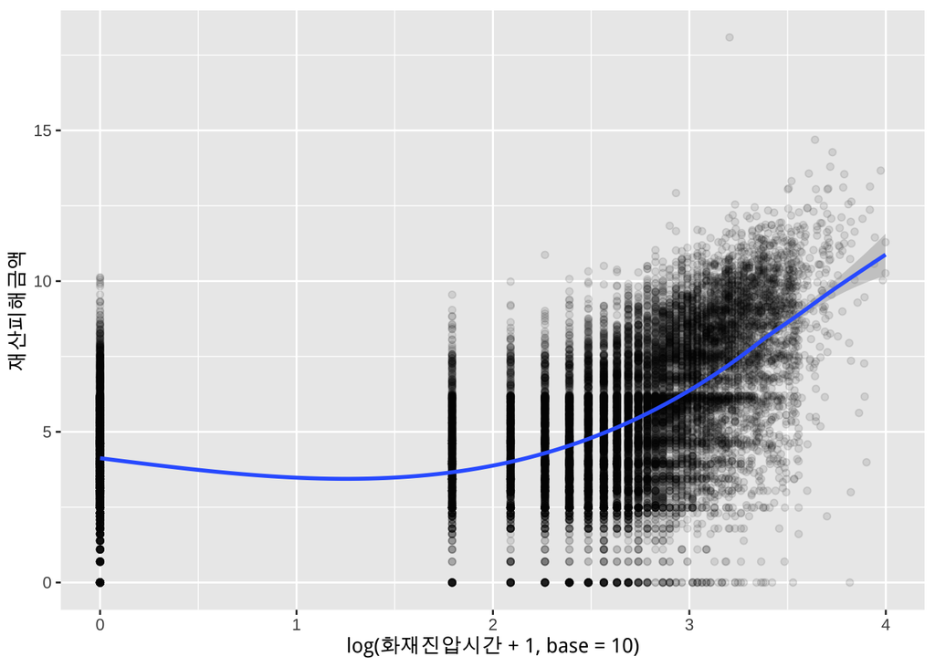

```r
data %>%
  filter(화재진압시간 < 10000)%>%
  ggplot(aes(log(화재진압시간+1, base = 10), 재산피해금액))+
  geom_point(alpha = 0.1)+
  geom_smooth()
```

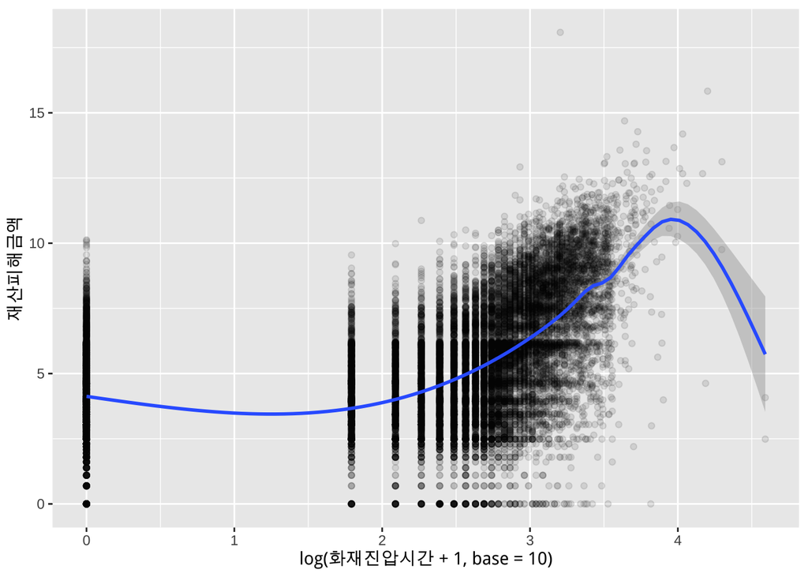

```r
data %>%
  ggplot(aes(log(화재진압시간+1, base = 10), 재산피해금액))+
  geom_point(alpha = 0.1)+
  geom_smooth()
```